# cellmig: quantifying cell migration with hierarchical Bayesian models

Simo Kitanovski (simo.kitanovski@uni-due.de)

28 Juli 2025

# 1 Background

```r
library(cellmig)
library(ggplot2)
library(ggforce)
library(patchwork)
library(skimr)
ggplot2::theme_set(new = theme_bw(base_size = 10))
```

# 2 Background

Cell migration is essential for many vital biological functions, for instance division or differentiation, and it impacts pathological processes including cancer metastasis. High-throughput tracking of cells with time-lapse microscopy followed by the acquisition of images at ﬁxed time intervals facilitates the analysis of cell velocity across many wells treated under different biological conditions, followed by computational image processing to extract quantitative cell velocities and to detect changes following perturbations such as drug treatments. However, these workflows generate considerable technical noise (e.g., imaging artifacts, unprecise pipetting) and biological variability (e.g., cell-to-cell heterogeneity), and therefore technical and biological replicates are necessary, leading to large, hierarchically structured datasets: cells are nested within technical replicates that are nested within biological replicates.

Current statistical analyses of such data rely on qualitative approaches, or inadequate statistical methods that usually ignore the hierarchical structure of the data and fail to explicitly quantify uncertainty arising from technical or biological variability. To address this gap, we present cellmig, an R package implementing Bayesian hierarchical models for migration analysis. cellmig quantifies condition-specific velocity changes (e.g., drug effects) while modeling nested data structures and technical artifacts, providing uncertainty-aware estimates through credible intervals. It further enables synthetic data generation for experimental design optimization.

# 3 Data

This is how a typical cell migration data looks like $\rightarrow$ a table.

Each rows is a cell with the following features:

- well = unique well ID (w1, w2, w3, etc.).
- plate = unique plate ID (p1, p2, p3, etc.). Each plate is a biological replicate. A plate contains multiple wells, some of which are treated with the same compound and dose (technical replicates)
- compound = compound name (c1, c2, c3, etc.)
- dose = compound concentration (0, 1, 5, 10, low, mid, high, etc.)
- v = Observed cell migration velocity (numeric)
- offset = binary (0 or 1). Indicates whether a treatment should be used for batch correction across plates. By default offset = 0 (no correction). Set to 1 for specific treatment groups (compound x dose) used as offsets. Ensure that this treatment group appears on each plate.

```r
data("d", package = "cellmig")
str(d)
```

```
FALSE 'data.frame': 7560 obs. of  6 variables:
FALSE  $ well    : chr  "1" "1" "1" "1" ...
FALSE  $ plate   : chr  "1" "1" "1" "1" ...
FALSE  $ compound: chr  "C1" "C1" "C1" "C1" ...
FALSE  $ dose    : chr  "D1" "D1" "D1" "D1" ...
FALSE  $ v       : num  21.905 0.535 3.348 5.351 1.194 ...
FALSE  $ offset  : num  1 1 1 1 1 1 1 1 1 1 ...
```

In this vignette we will use simulated data from:

- **plates** ($p$): 1, 2, … , 3
- **wells** ($w$): 1, 2, … , 378
- **cells** per well with their migration velocity `v`
- wells are treated with **compounds** 1, 2, …, 6 at **dose** 1, 2, …, 7.
- combination of a compound and dose is a **treatment** ($t$) $\rightarrow$ 1, 2, …, 42.

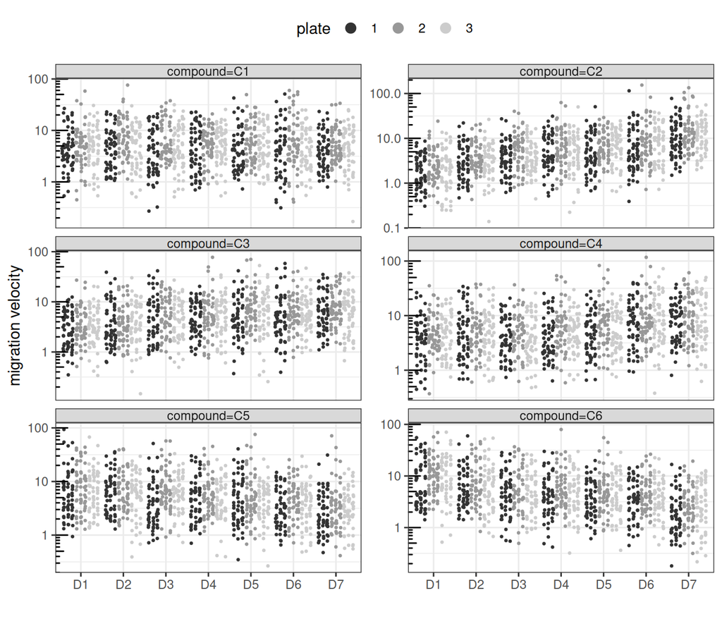

```r
ggplot(data = d)+
  facet_wrap(facets = ~paste0("compound=", compound), scales = "free_y", ncol = 2)+
  geom_sina(aes(x = as.factor(dose), col = plate, y = v, group = well), size = 0.5)+
  theme_bw()+
  theme(legend.position = "top",
        strip.text.x = element_text(margin = margin(0.03,0,0.03,0, "cm")))+
  ylab(label = "migration velocity")+
  xlab(label = '')+
  scale_color_grey()+
  guides(color = guide_legend(override.aes = list(size = 3)))+
  guides(shape = guide_legend(override.aes = list(size = 3)))+
  scale_y_log10()+
  annotation_logticks(base = 10, sides = "l")
```

## 3.1 **Mean migration velocity** per well

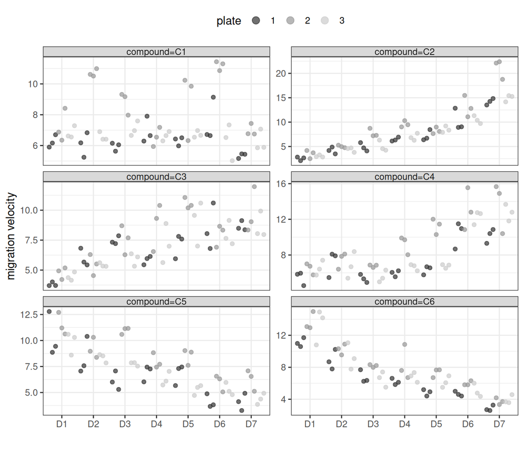

```r
dm <- aggregate(v~well+plate+compound+dose, data = d, FUN = mean)
ggplot(data = dm)+
  facet_wrap(facets = ~paste0("compound=", compound), scales = "free_y", ncol = 2)+
  geom_sina(aes(x = as.factor(dose), col = plate, y = v, group = well),
            size = 1.5, alpha = 0.7)+
  theme_bw()+
  theme(legend.position = "top",
        strip.text.x = element_text(margin = margin(0.03,0,0.03,0, "cm")))+
  ylab(label = "migration velocity")+
  xlab(label = '')+
  scale_color_grey()+
  guides(color = guide_legend(override.aes = list(size = 3)))+
  guides(shape = guide_legend(override.aes = list(size = 3)))
```

# 4 Model fitting

```r
o <- cellmig(x = d,
             control = list(mcmc_warmup = 300,
                            mcmc_steps = 1000,
                            mcmc_chains = 3,
                            mcmc_cores = 3,
                            mcmc_algorithm = "NUTS",
                            adapt_delta = 0.8,
                            max_treedepth = 10))
```

## 4.1 What are the **overall treatment effects** ($\delta$) on cell migration velocity?

- Dot = mean $\delta$
- Error bar = 95% HDI of $\delta$
- $\exp(\delta)$ = fold change in cell velocity relative to control

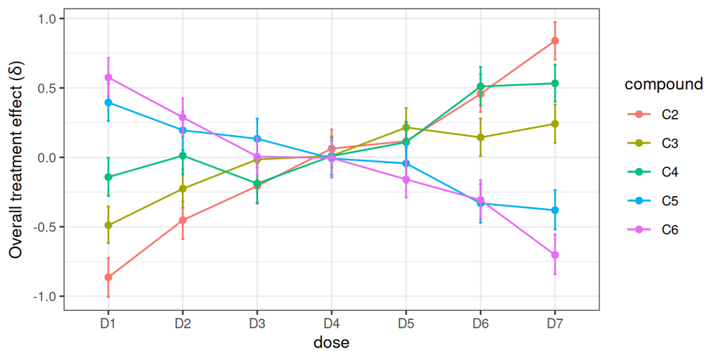

```r
ggplot(data = o$posteriors$mu_group)+
  geom_line(aes(x = dose, y = mean, col = compound, group = compound))+
  geom_point(aes(x = dose, y = mean, col = compound))+
  geom_errorbar(aes(x = dose, y = mean, ymin = X2.5., ymax = X97.5.,
                    col = compound), width = 0.04)+
  ylab(label = expression("Overall treatment effect ("*delta*")"))
```

## 4.2 Compare the dose-response `profiles` for different compounds

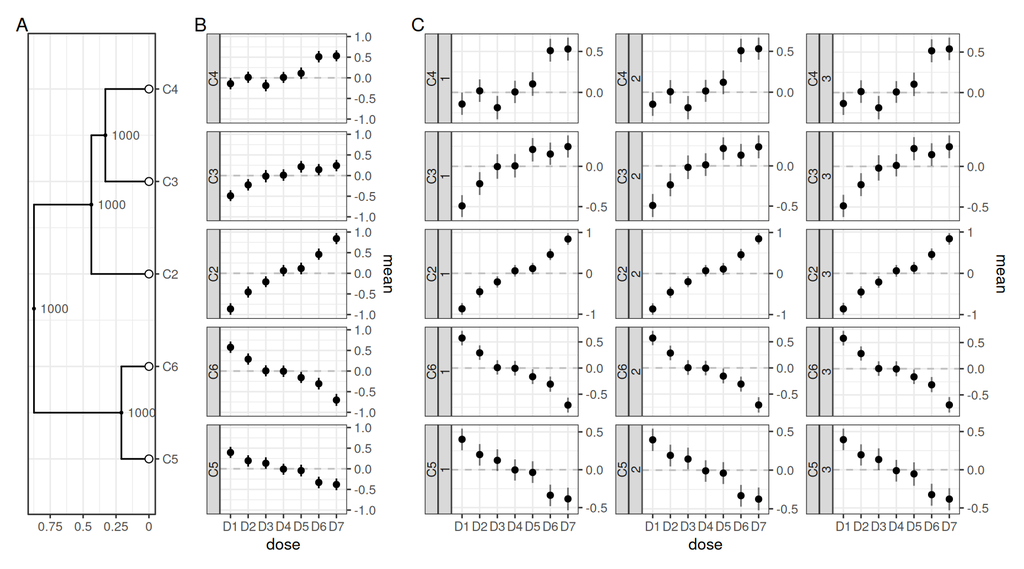

```r
get_dose_response_profile(x = o)+
  patchwork::plot_layout(widths = c(1, 1, 4))
```

## 4.3 Compare the treatment group `profiles`

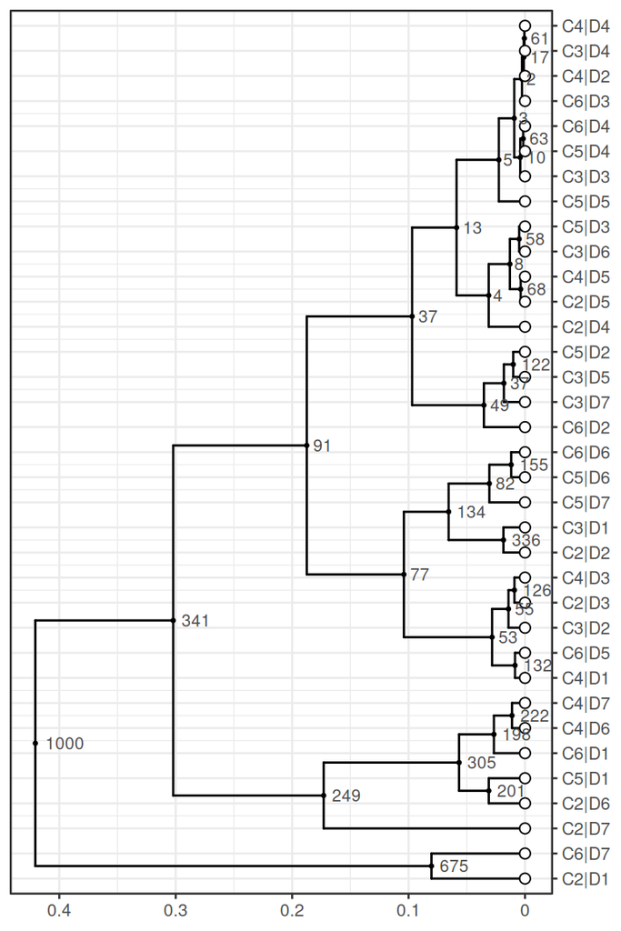

```r
get_treatment_profile(x = o,
                      hc_link = "average",
                      hc_dist = "euclidean",
                      select_gs = get_groups(o)$group,
                      B = 1000)
```

# 5 Compare the effects between treatment group

## 5.1 Pairwise dot-plot comparison $\rightarrow$ x minus y axis

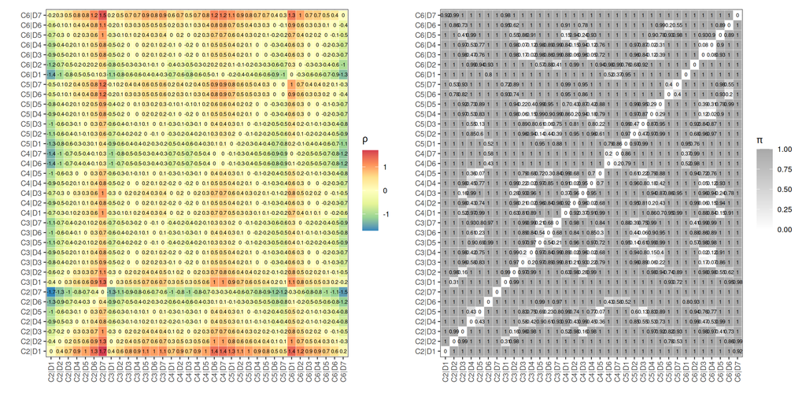

```r
u <- get_pairs(x = o)
u$plot
```

## 5.2 Violin plot based comparison

- from_groups: vector of treatment groups to consider (combinations of compounds and doses)
- to_group: target treatment group
- violins show the posterior distributions of the differences ($\rho$: each element from `from_groups` vs. `to_group`).
- label: probability, $\pi$, of observing completely positive or negative $\rho$

```r
get_groups(x = o)
```

```
FALSE    group_id group compound dose
FALSE 1         1 C2|D1       C2   D1
FALSE 2         2 C2|D2       C2   D2
FALSE 3         3 C2|D3       C2   D3
FALSE 4         4 C2|D4       C2   D4
FALSE 5         5 C2|D5       C2   D5
FALSE 6         6 C2|D6       C2   D6
FALSE 7         7 C2|D7       C2   D7
FALSE 8         8 C3|D1       C3   D1
FALSE 9         9 C3|D2       C3   D2
FALSE 10       10 C3|D3       C3   D3
FALSE 11       11 C3|D4       C3   D4
FALSE 12       12 C3|D5       C3   D5
FALSE 13       13 C3|D6       C3   D6
FALSE 14       14 C3|D7       C3   D7
FALSE 15       15 C4|D1       C4   D1
FALSE 16       16 C4|D2       C4   D2
FALSE 17       17 C4|D3       C4   D3
FALSE 18       18 C4|D4       C4   D4
FALSE 19       19 C4|D5       C4   D5
FALSE 20       20 C4|D6       C4   D6
FALSE 21       21 C4|D7       C4   D7
FALSE 22       22 C5|D1       C5   D1
FALSE 23       23 C5|D2       C5   D2
FALSE 24       24 C5|D3       C5   D3
FALSE 25       25 C5|D4       C5   D4
FALSE 26       26 C5|D5       C5   D5
FALSE 27       27 C5|D6       C5   D6
FALSE 28       28 C5|D7       C5   D7
FALSE 29       29 C6|D1       C6   D1
FALSE 30       30 C6|D2       C6   D2
FALSE 31       31 C6|D3       C6   D3
FALSE 32       32 C6|D4       C6   D4
FALSE 33       33 C6|D5       C6   D5
FALSE 34       34 C6|D6       C6   D6
FALSE 35       35 C6|D7       C6   D7
```

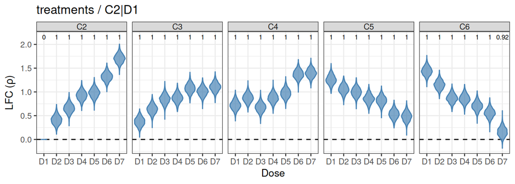

```r
u <- get_violins(x = o,
                 from_groups = get_groups(x = o)$group,
                 to_group = "C2|D1")
u$plot
```

# 6 Posterior predictive checks (PPCs)

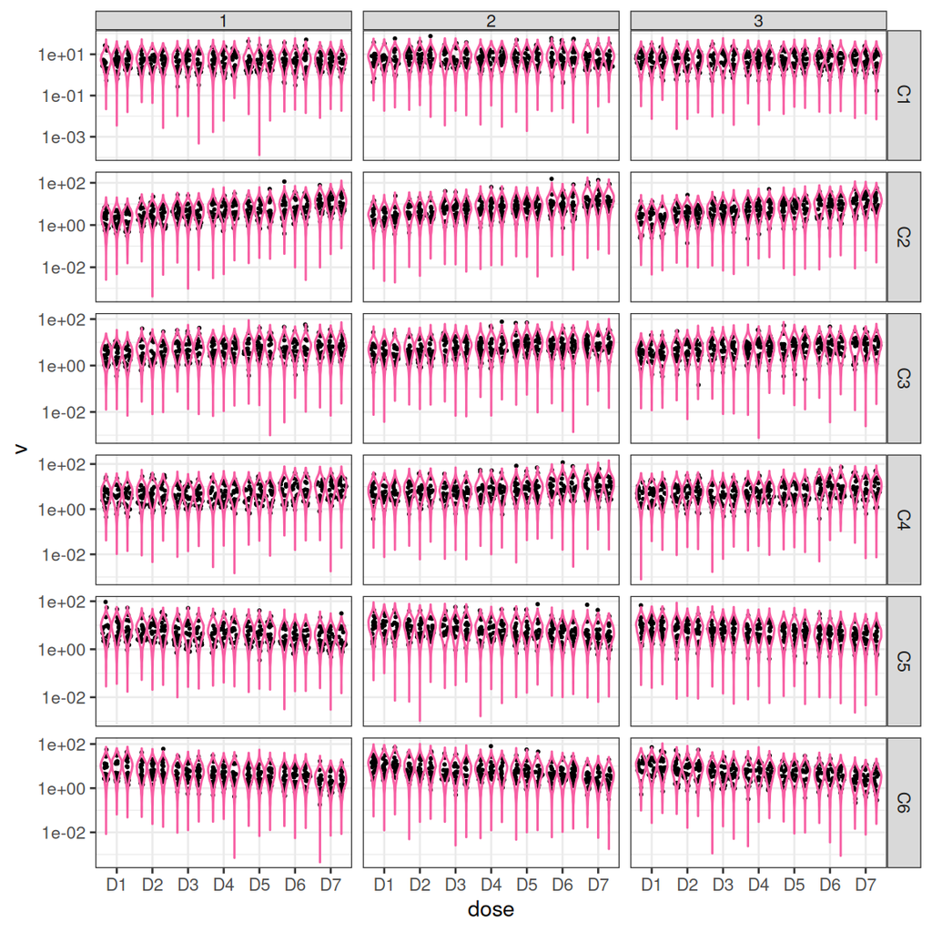

```r
g <- get_ppc_violins(x = o)
g+scale_y_log10()
```

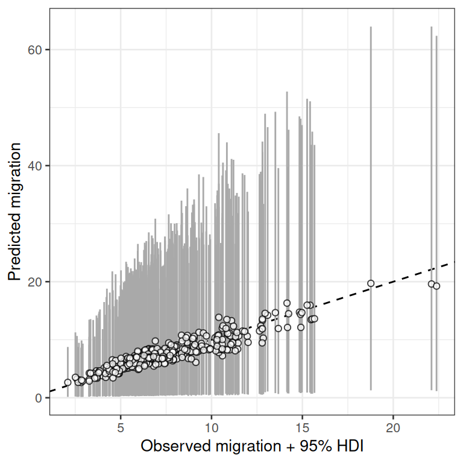

```r
g <- get_ppc_means(x = o)
g
```

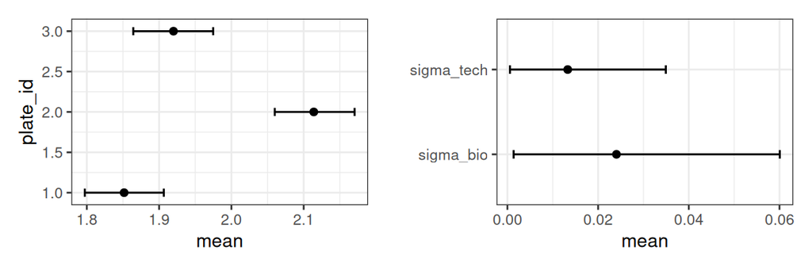

[output not shown]

```r
g_alpha_p <- ggplot(data = o$posteriors$alpha_p)+
  geom_errorbarh(aes(y = plate_id, x = mean, xmin = X2.5., xmax = X97.5.),
                 height = 0.1)+
  geom_point(aes(y = plate_id, x = mean))

g_sigma <- ggplot()+
  geom_errorbarh(data = o$posteriors$sigma_bio,
                 aes(y = "sigma_bio",
                     x = mean, xmin = X2.5., xmax = X97.5.),
                 height = 0.1)+
  geom_errorbarh(data = o$posteriors$sigma_tech,
                 aes(y = "sigma_tech",
                     x = mean, xmin = X2.5., xmax = X97.5.),
                 height = 0.1)+
  geom_point(data = o$posteriors$sigma_bio,
             aes(y = "sigma_bio", x = mean))+
  geom_point(data = o$posteriors$sigma_tech,
             aes(y = "sigma_tech", x = mean))+
  ylab(label = '')

g_alpha_p|g_sigma
```